# Environmental and human factors shape the trophic ecology of a widespread marine predator

Part 3: GAM fitting and selection

Elena FERNÁNDEZ CORREDOR elenafcorr@proton.me

Version: 27 febrero, 2025

```r
# Loading spatial / graphical libraries
library(gstat)
library(sp)
library(tidyverse)
library(readxl)
library(mgcv)
library(readr)
library(magrittr)
library(caret) #for Cross Validation

# import data #####
SIA_SWO  <-  read.table(file = "results_mixsiar_drivers.csv", sep  = ";", header = T) %>%
  drop_na(cepha)

# Group prey
prey_grouped <- SIA_SWO %>%
  mutate(
    fish = bathy + gadipela,
    ceph = cepha + cepha2) %>%
  drop_na(ceph)
```

# 1 GAM ranking

```r
# Create a vector of variable names
variables <- c("s(LJFL, k=5)", "s(depth, k=5)", "s(MLD, k=5)", "s(Chlmean, k=5)","s(SST, k=5)","s(fishing_effort, k=5)")

# Generate all possible combinations of variables
combinations <- lapply(1:length(variables), function(x) combn(variables, x, simplify = FALSE))
```

## 1.1 Fish

```r
# Initialize a list to store the models
models_fish <- list()

# Create a data frame to store the deviance and AIC values
rank_fish <- data.frame(
  Model = character(),
  Deviance = double(),
  AIC = double()
)

# Fit a GAM for each combination of variables
# run the gams
a=Sys.time()
for (comb in unlist(combinations, recursive = FALSE)) {
  formula_str <- as.formula(paste("fish  ~  te(LON,LAT) +", paste(comb, collapse = " + ")))
  model <- gam(formula_str, data = prey_grouped, family = betar(link = "logit"))
  models_fish[[paste(comb, collapse = ", ")]] <- model
}
Sys.time()-a

# Iterate through models and calculate deviance and AIC
for (model_name in names(models_fish)) {
  model <- models_fish[[model_name]]

  # Calculate AIC
  aic <- AIC(model)

  # Calculate deviance
  deviance_explained <- summary(model)$dev.expl

  # Add the results to the data frame
  rank_fish <- rbind(rank_fish, data.frame(
    Model = paste("fish  ~  te(LON,LAT)  + ", model_name),
    Deviance = deviance_explained,
    AIC = aic
  ))
}
```

## 1.2 Squid

```r
# Initialize a list to store the models
models_ceph <- list()

# Create a data frame to store the deviance and AIC values
rank_ceph <- data.frame(
  Model = character(),
  Deviance = double(),
  AIC = double()
)

# Fit a GAM for each combination of variables
# run the models
a=Sys.time()
for (comb in unlist(combinations, recursive = FALSE)) {

  formula_str <- as.formula(paste("ceph  ~ te(LON,LAT) +", paste(comb, collapse = " + ")))
  model <- gam(formula_str, data = prey_grouped, family = betar(link = "logit"))
  models_ceph[[paste(comb, collapse = ", ")]] <- model
}
Sys.time()-a

# Iterate through models and calculate deviance and AIC
for (model_name in names(models_ceph)) {
  model <- models_ceph[[model_name]]

  # Calculate AIC
  aic <- AIC(model)

  # Calculate deviance
  deviance_explained <- summary(model)$dev.expl

  # Add the results to the data frame
  rank_ceph <- rbind(rank_ceph, data.frame(
    Model = paste("ceph ~ te(LON,LAT) +", model_name),
    Deviance = deviance_explained,
    AIC = aic
  ))
}
```

## 1.3 Gelatinous

```r
# Initialize a list to store the models
models_gela <- list()

# Create a data frame to store the deviance and AIC values
rank_gela <- data.frame(
  Model = character(),
  Deviance = double(),
  AIC = double()
)
# Fit a GAM for each combination of variables
# run the models
a=Sys.time()
for (comb in unlist(combinations, recursive = FALSE)) {

  formula_str <- as.formula(paste("gela  ~ te(LON,LAT) +  ", paste(comb, collapse = " + ")))
  model <- gam(formula_str, data = prey_grouped, family = betar(link = "logit"))
  models_gela[[paste(comb, collapse = ", ")]] <- model
}
Sys.time()-a

# Iterate through models and calculate deviance and AIC
for (model_name in names(models_gela)) {
  model <- models_gela[[model_name]]

  # Calculate AIC
  aic <- AIC(model)

  # Calculate deviance
  deviance_explained <- summary(model)$dev.expl

  # Add the results to the data frame
  rank_gela <- rbind(rank_gela, data.frame(
    Model = paste("gela ~ te(LON,LAT) + ", model_name),
    Deviance = deviance_explained,
    AIC = as.numeric(aic)
  ))
}
```

## 1.4 Top ranked models with lowest AIC

### 1.4.1 Fish

Null model

```r
fish_NULL <- gam(fish ~ te(LON,LAT), data=prey_grouped, family = betar(link = "logit"))
summary(fish_NULL)
```

```
##
## Family: Beta regression(70.094)
## Link function: logit
##
## Formula:
## fish ~ te(LON, LAT)
##
## Parametric coefficients:
##             Estimate Std. Error z value Pr(>|z|)
## (Intercept) -1.33212    0.01887  -70.61   <2e-16 ***
## ---
## Signif. codes:  0 '***' 0.001 '**' 0.01 '*' 0.05 '.' 0.1 ' ' 1
##
## Approximate significance of smooth terms:
##               edf Ref.df Chi.sq p-value
## te(LON,LAT) 10.52   12.1  230.6  <2e-16 ***
## ---
## Signif. codes:  0 '***' 0.001 '**' 0.01 '*' 0.05 '.' 0.1 ' ' 1
##
## R-sq.(adj) =  0.495   Deviance explained =   52%
## -REML = -380.1  Scale est. = 1         n = 241
```

lowest AIC: fish ~ te(LON,LAT) + s(MLD, k=5), s(SST, k=5), s(fishing_effort, k=5)

```r
fish_1 <-  gam(fish ~ te(LON,LAT)  + s(MLD, k=5) + SST +  s(fishing_effort, k=5), data=prey_grouped, family = betar(link = "logit"))
summary(fish_1)
```

```
##
## Family: Beta regression(74.379)
## Link function: logit
##
## Formula:
## fish ~ te(LON, LAT) + s(MLD, k = 5) + SST + s(fishing_effort,
##     k = 5)
##
## Parametric coefficients:
##             Estimate Std. Error z value Pr(>|z|)
## (Intercept) -6.73798    1.64791  -4.089 4.34e-05 ***
## SST          0.27081    0.08255   3.280  0.00104 **
## ---
## Signif. codes:  0 '***' 0.001 '**' 0.01 '*' 0.05 '.' 0.1 ' ' 1
##
## Approximate significance of smooth terms:
##                     edf Ref.df Chi.sq  p-value
## te(LON,LAT)       5.083  5.846 33.318 1.62e-05 ***
## s(MLD)            2.373  2.861 28.441 3.34e-06 ***
## s(fishing_effort) 2.077  2.524  3.906    0.161
## ---
## Signif. codes:  0 '***' 0.001 '**' 0.01 '*' 0.05 '.' 0.1 ' ' 1
##
## R-sq.(adj) =  0.524   Deviance explained = 54.7%
## -REML = -387.53  Scale est. = 1         n = 241
```

2nd AIC: fish ~ te(LON,LAT) + s(LJFL, k=5), s(MLD, k=5), s(SST, k=5), s(fishing_effort, k=5)

```r
fish_2 <-  gam(fish ~ te(LON,LAT)  +  s(LJFL, k=5) + s(MLD, k=5)  + SST +  s(fishing_effort, k=5), data=prey_grouped, family = betar(link = "logit"))
summary(fish_2)
```

```
##
## Family: Beta regression(75.359)
## Link function: logit
##
## Formula:
## fish ~ te(LON, LAT) + s(LJFL, k = 5) + s(MLD, k = 5) + SST +
##     s(fishing_effort, k = 5)
##
## Parametric coefficients:
##             Estimate Std. Error z value Pr(>|z|)
## (Intercept) -6.69072    1.62439  -4.119 3.81e-05 ***
## SST          0.26845    0.08137   3.299 0.000971 ***
## ---
## Signif. codes:  0 '***' 0.001 '**' 0.01 '*' 0.05 '.' 0.1 ' ' 1
##
## Approximate significance of smooth terms:
##                     edf Ref.df Chi.sq  p-value
## te(LON,LAT)       4.806  5.528 30.039 6.69e-05 ***
## s(LJFL)           2.974  3.498  5.378    0.418
## s(MLD)            2.344  2.827 29.563 1.18e-06 ***
## s(fishing_effort) 1.979  2.413  2.929    0.245
## ---
## Signif. codes:  0 '***' 0.001 '**' 0.01 '*' 0.05 '.' 0.1 ' ' 1
##
## R-sq.(adj) =  0.528   Deviance explained = 55.8%
## -REML = -384.9  Scale est. = 1         n = 241
```

3rd AIC: fish ~ te(LON,LAT) + s(MLD, k=5), s(SST, k=5)

```r
fish_3<-  gam(fish ~ te(LON,LAT) + s(MLD, k=5) + SST, data=prey_grouped, family = betar(link = "logit"))
summary(fish_3)
```

```
##
## Family: Beta regression(72.976)
## Link function: logit
##
## Formula:
## fish ~ te(LON, LAT) + s(MLD, k = 5) + SST
##
## Parametric coefficients:
##             Estimate Std. Error z value Pr(>|z|)
## (Intercept) -6.28865    1.62826  -3.862 0.000112 ***
## SST          0.24831    0.08157   3.044 0.002334 **
## ---
## Signif. codes:  0 '***' 0.001 '**' 0.01 '*' 0.05 '.' 0.1 ' ' 1
##
## Approximate significance of smooth terms:
##               edf Ref.df Chi.sq  p-value
## te(LON,LAT) 4.940  5.810  27.55 0.000105 ***
## s(MLD)      2.476  2.978  33.54 6.86e-08 ***
## ---
## Signif. codes:  0 '***' 0.001 '**' 0.01 '*' 0.05 '.' 0.1 ' ' 1
##
## R-sq.(adj) =  0.512   Deviance explained = 53.4%
## -REML = -388.74  Scale est. = 1         n = 241
```

4TH AIC fish ~ te(LON,LAT) + s(LJFL, k=5) + s(MLD, k=5), s(SST, k=5)

```r
fish_4 <-  gam(fish ~ te(LON,LAT) +  s(LJFL, k=5) + s(MLD, k=5)  + SST, data=prey_grouped, family = betar(link = "logit"))
summary(fish_4)
```

```
##
## Family: Beta regression(74.147)
## Link function: logit
##
## Formula:
## fish ~ te(LON, LAT) + s(LJFL, k = 5) + s(MLD, k = 5) + SST
##
## Parametric coefficients:
##             Estimate Std. Error z value Pr(>|z|)
## (Intercept) -6.29520    1.56009  -4.035 5.46e-05 ***
## SST          0.24864    0.07815   3.181  0.00147 **
## ---
## Signif. codes:  0 '***' 0.001 '**' 0.01 '*' 0.05 '.' 0.1 ' ' 1
##
## Approximate significance of smooth terms:
##               edf Ref.df Chi.sq  p-value
## te(LON,LAT) 4.447  5.201 25.026 0.000205 ***
## s(LJFL)     3.000  3.521  6.778 0.285064
## s(MLD)      2.372  2.864 36.267 6.72e-07 ***
## ---
## Signif. codes:  0 '***' 0.001 '**' 0.01 '*' 0.05 '.' 0.1 ' ' 1
##
## R-sq.(adj) =  0.517   Deviance explained = 54.7%
## -REML = -386.59  Scale est. = 1         n = 241
```

5TH AIC fish ~ te(LON,LAT) + s(MLD, k=5), s(Chlmean, k=5), s(SST, k=5), s(fishing_effort, k=5)

```r
fish_5 <-  gam(fish ~ te(LON,LAT)  + s(MLD, k=5)  + SST +  s(fishing_effort, k=5) + Chlmean, data=prey_grouped, family = betar(link = "logit"))
summary(fish_5)
```

```
##
## Family: Beta regression(73.967)
## Link function: logit
##
## Formula:
## fish ~ te(LON, LAT) + s(MLD, k = 5) + SST + s(fishing_effort,
##     k = 5) + Chlmean
##
## Parametric coefficients:
##             Estimate Std. Error z value Pr(>|z|)
## (Intercept) -6.26741    1.73438  -3.614 0.000302 ***
## SST          0.25034    0.08534   2.933 0.003353 **
## Chlmean     -0.32709    0.47707  -0.686 0.492944
## ---
## Signif. codes:  0 '***' 0.001 '**' 0.01 '*' 0.05 '.' 0.1 ' ' 1
##
## Approximate significance of smooth terms:
##                     edf Ref.df Chi.sq  p-value
## te(LON,LAT)       4.674  5.351 19.131  0.00252 **
## s(MLD)            2.395  2.900 25.582 1.21e-05 ***
## s(fishing_effort) 1.998  2.439  3.715  0.17159
## ---
## Signif. codes:  0 '***' 0.001 '**' 0.01 '*' 0.05 '.' 0.1 ' ' 1
##
## R-sq.(adj) =  0.521   Deviance explained = 54.6%
## -REML = -387.92  Scale est. = 1         n = 241
```

#### 1.4.1.1 Cross validation

```r
validation <-data.frame(
  model = character(),
  aic = double(),
  deviance = double(),
  rmse_mean = double(),
  mape_mean = double(),
  pearson_mean = double())

fish_m <- list(fish_NULL, fish_1, fish_2, fish_3, fish_5)

for(j in fish_m){

  print(formula(j))
  rmse <- list()
  mape <- list()
  pear <- list()

  # Apply cross-validation:
  set.seed(998)  # For reproducibility

  # Split the data into a training set and a test set:
  inTraining <- list()
  training <- list()
  testing <- list()
  k <- 25
  set.seed(235655)
  set <- sample(1:235465775, 25)
  for(i in 1:k) {

    set.seed(set[i])
    inTraining[[i]] <- createDataPartition(prey_grouped$fish, p = .75, list = FALSE)
    training[[i]] <- prey_grouped[ inTraining[[i]],]
    testing[[i]]  <- prey_grouped[-inTraining[[i]],]
  }

  fish_train <- list()
  fish_test <- list()
  for(i in 1:k) {

    fish_train[[i]] <- gam(formula(j), data=training[[i]], family = betar(link = "logit"))
    fish_test[[i]] <- predict(fish_train[[i]], newdata = testing[[i]], se.fit = TRUE,type = "response")
  }


  for(i in 1:k) {

    rmse[[i]] <- Metrics::rmse(testing[[i]]$fish, fish_test[[i]]$fit)
    mape[[i]] <- Metrics::mape(testing[[i]]$fish, fish_test[[i]]$fit)
    pear[[i]] <- cor(testing[[i]]$fish, as.numeric(fish_test[[i]]$fit), method = "pearson")
  }

  # Add the results to the data frame
  validation <- rbind(validation, data.frame(
    model = paste(deparse(j$formula)),
    aic = AIC(j),
    deviance = summary(j)$dev.expl,
    rmse_mean = mean(unlist(rmse)),
    mape_mean = mean(unlist(mape)),
    pearson_mean = mean(unlist(pear))))
}
```

```
## fish ~ te(LON, LAT)
## fish ~ te(LON, LAT) + s(MLD, k = 5) + SST + s(fishing_effort,
##     k = 5)
## fish ~ te(LON, LAT) + s(LJFL, k = 5) + s(MLD, k = 5) + SST +
##     s(fishing_effort, k = 5)
## fish ~ te(LON, LAT) + s(MLD, k = 5) + SST
## fish ~ te(LON, LAT) + s(MLD, k = 5) + SST + s(fishing_effort,
##     k = 5) + Chlmean
```

```r
validation
```

```
##                                                            model       aic
## 1                                            fish ~ te(LON, LAT) -770.6616
## 2 fish ~ te(LON, LAT) + s(MLD, k = 5) + SST + s(fishing_effort,  -783.4922
## 3                                                         k = 5) -783.4922
## 4  fish ~ te(LON, LAT) + s(LJFL, k = 5) + s(MLD, k = 5) + SST +  -783.1464
## 5                                       s(fishing_effort, k = 5) -783.1464
## 6                      fish ~ te(LON, LAT) + s(MLD, k = 5) + SST -781.7923
## 7 fish ~ te(LON, LAT) + s(MLD, k = 5) + SST + s(fishing_effort,  -781.7398
## 8                                               k = 5) + Chlmean -781.7398
##    deviance  rmse_mean mape_mean pearson_mean
## 1 0.5197059 0.04669959 0.2137562    0.6948013
## 2 0.5472502 0.04604541 0.2097431    0.7058471
## 3 0.5472502 0.04604541 0.2097431    0.7058471
## 4 0.5582767 0.04657621 0.2117824    0.6979637
## 5 0.5582767 0.04657621 0.2117824    0.6979637
## 6 0.5343406 0.04619752 0.2097981    0.7040725
## 7 0.5456908 0.04656618 0.2121607    0.6979196
## 8 0.5456908 0.04656618 0.2121607    0.6979196
```

### 1.4.2 Squid

lowest AIC: ceph ~ te(LON,LAT) + s(LJFL, k=5), s(SST, k=5), s(fishing_effort, k=5)

```r
ceph_null <- gam(ceph ~ te(LON,LAT), data=prey_grouped, family = betar(link = "logit"))
summary(ceph_null)
```

```
##
## Family: Beta regression(22.235)
## Link function: logit
##
## Formula:
## ceph ~ te(LON, LAT)
##
## Parametric coefficients:
##             Estimate Std. Error z value Pr(>|z|)
## (Intercept)  0.57772    0.02875   20.09   <2e-16 ***
## ---
## Signif. codes:  0 '***' 0.001 '**' 0.01 '*' 0.05 '.' 0.1 ' ' 1
##
## Approximate significance of smooth terms:
##               edf Ref.df Chi.sq p-value
## te(LON,LAT) 12.82  14.41  405.2  <2e-16 ***
## ---
## Signif. codes:  0 '***' 0.001 '**' 0.01 '*' 0.05 '.' 0.1 ' ' 1
##
## R-sq.(adj) =  0.657   Deviance explained = 67.6%
## -REML = -209.11  Scale est. = 1         n = 241
```

```r
#1
ceph1 <- gam(ceph ~ te(LON,LAT) + s(LJFL, k =5), data=prey_grouped, family = betar(link = "logit"))
summary(ceph1)
```

```
##
## Family: Beta regression(23.561)
## Link function: logit
##
## Formula:
## ceph ~ te(LON, LAT) + s(LJFL, k = 5)
##
## Parametric coefficients:
##             Estimate Std. Error z value Pr(>|z|)
## (Intercept)  0.57940    0.02803   20.67   <2e-16 ***
## ---
## Signif. codes:  0 '***' 0.001 '**' 0.01 '*' 0.05 '.' 0.1 ' ' 1
##
## Approximate significance of smooth terms:
##                edf Ref.df Chi.sq p-value
## te(LON,LAT) 12.321 13.906 368.93 < 2e-16 ***
## s(LJFL)      3.226  3.698  18.72 0.00172 **
## ---
## Signif. codes:  0 '***' 0.001 '**' 0.01 '*' 0.05 '.' 0.1 ' ' 1
##
## R-sq.(adj) =  0.679   Deviance explained = 69.8%
## -REML = -212.57  Scale est. = 1         n = 241
```

4TH AIC ceph ~ te(LON,LAT) + s(LJFL, k=5), s(fishing_effort, k=5)

```r
#2
ceph2<- gam(ceph ~ te(LON,LAT) + s(LJFL, k = 5) + s(fishing_effort, k = 5), data=prey_grouped, family = betar(link = "logit"))
summary(ceph2)
```

```
##
## Family: Beta regression(24.632)
## Link function: logit
##
## Formula:
## ceph ~ te(LON, LAT) + s(LJFL, k = 5) + s(fishing_effort, k = 5)
##
## Parametric coefficients:
##             Estimate Std. Error z value Pr(>|z|)
## (Intercept)  0.58183    0.02749   21.17   <2e-16 ***
## ---
## Signif. codes:  0 '***' 0.001 '**' 0.01 '*' 0.05 '.' 0.1 ' ' 1
##
## Approximate significance of smooth terms:
##                      edf Ref.df Chi.sq p-value
## te(LON,LAT)       11.330 12.873 236.23 < 2e-16 ***
## s(LJFL)            3.510  3.870  21.00 0.00071 ***
## s(fishing_effort)  3.582  3.857  13.76 0.00574 **
## ---
## Signif. codes:  0 '***' 0.001 '**' 0.01 '*' 0.05 '.' 0.1 ' ' 1
##
## R-sq.(adj) =  0.693   Deviance explained = 71.5%
## -REML = -212.87  Scale est. = 1         n = 241
```

5TH ceph ~ te(LON,LAT) + s(LJFL, k=5) + s(SST, k=5)

```r
#3
ceph3<- gam(ceph ~ te(LON,LAT) + s(LJFL, k = 5) + SST, data=prey_grouped, family = betar(link = "logit"))
summary(ceph3)
```

```
##
## Family: Beta regression(23.947)
## Link function: logit
##
## Formula:
## ceph ~ te(LON, LAT) + s(LJFL, k = 5) + SST
##
## Parametric coefficients:
##             Estimate Std. Error z value Pr(>|z|)
## (Intercept)   9.1658     4.8312   1.897   0.0578 .
## SST          -0.4303     0.2421  -1.777   0.0755 .
## ---
## Signif. codes:  0 '***' 0.001 '**' 0.01 '*' 0.05 '.' 0.1 ' ' 1
##
## Approximate significance of smooth terms:
##                edf Ref.df Chi.sq p-value
## te(LON,LAT) 12.350 13.932 377.03 < 2e-16 ***
## s(LJFL)      3.215  3.691  19.16 0.00135 **
## ---
## Signif. codes:  0 '***' 0.001 '**' 0.01 '*' 0.05 '.' 0.1 ' ' 1
##
## R-sq.(adj) =  0.683   Deviance explained = 70.4%
## -REML = -213.59  Scale est. = 1         n = 241
```

```r
ceph <- gam(ceph ~ te(LON,LAT) + s(LJFL, k = 5)  + SST + s(fishing_effort, k = 5), data=prey_grouped, family = betar(link = "logit"))
summary(ceph)
```

```
##
## Family: Beta regression(24.741)
## Link function: logit
##
## Formula:
## ceph ~ te(LON, LAT) + s(LJFL, k = 5) + SST + s(fishing_effort,
##     k = 5)
##
## Parametric coefficients:
##             Estimate Std. Error z value Pr(>|z|)
## (Intercept)   8.3765     4.2652   1.964   0.0495 *
## SST          -0.3906     0.2137  -1.828   0.0676 .
## ---
## Signif. codes:  0 '***' 0.001 '**' 0.01 '*' 0.05 '.' 0.1 ' ' 1
##
## Approximate significance of smooth terms:
##                      edf Ref.df Chi.sq  p-value
## te(LON,LAT)       10.899 12.491 195.36  < 2e-16 ***
## s(LJFL)            3.495  3.862  20.80 0.000744 ***
## s(fishing_effort)  3.522  3.819  13.29 0.006284 **
## ---
## Signif. codes:  0 '***' 0.001 '**' 0.01 '*' 0.05 '.' 0.1 ' ' 1
##
## R-sq.(adj) =  0.694   Deviance explained = 71.7%
## -REML = -213.81  Scale est. = 1         n = 241
```

2ND ceph ~ te(LON,LAT) + s(LJFL, k=5), s(Chlmean, k=5), s(fishing_effort, k=5)

```r
ceph4 = gam(ceph ~ te(LON,LAT) + s(LJFL, k = 5)  + s(Chlmean, k=5)+ s(fishing_effort, k = 5), data=prey_grouped, family = betar(link = "logit"))
summary(ceph4)
```

```
##
## Family: Beta regression(24.737)
## Link function: logit
##
## Formula:
## ceph ~ te(LON, LAT) + s(LJFL, k = 5) + s(Chlmean, k = 5) + s(fishing_effort,
##     k = 5)
##
## Parametric coefficients:
##             Estimate Std. Error z value Pr(>|z|)
## (Intercept)  0.58362    0.02745   21.26   <2e-16 ***
## ---
## Signif. codes:  0 '***' 0.001 '**' 0.01 '*' 0.05 '.' 0.1 ' ' 1
##
## Approximate significance of smooth terms:
##                     edf Ref.df Chi.sq  p-value
## te(LON,LAT)       8.595 10.053 185.31  < 2e-16 ***
## s(LJFL)           3.580  3.900  22.48 0.000115 ***
## s(Chlmean)        2.720  3.152  15.95 0.001589 **
## s(fishing_effort) 3.705  3.917  21.75 0.000184 ***
## ---
## Signif. codes:  0 '***' 0.001 '**' 0.01 '*' 0.05 '.' 0.1 ' ' 1
##
## R-sq.(adj) =  0.695   Deviance explained = 71.6%
## -REML = -214.44  Scale est. = 1         n = 241
```

3RD ceph ~ te(LON,LAT) + s(LJFL, k=5), s(Chlmean, k=5), s(SST, k=5), s(fishing_effort, k=5)

```r
ceph5 = gam(ceph ~ te(LON,LAT) + s(LJFL, k = 5)  + s(Chlmean, k=5) + SST + s(fishing_effort, k = 5), data=prey_grouped, family = betar(link = "logit"))
summary(ceph5)
```

```
##
## Family: Beta regression(24.832)
## Link function: logit
##
## Formula:
## ceph ~ te(LON, LAT) + s(LJFL, k = 5) + s(Chlmean, k = 5) + SST +
##     s(fishing_effort, k = 5)
##
## Parametric coefficients:
##             Estimate Std. Error z value Pr(>|z|)
## (Intercept)   5.0027     3.7872   1.321    0.187
## SST          -0.2215     0.1898  -1.167    0.243
##
## Approximate significance of smooth terms:
##                     edf Ref.df Chi.sq  p-value
## te(LON,LAT)       8.740 10.225 77.338  < 2e-16 ***
## s(LJFL)           3.566  3.895 21.685 0.000163 ***
## s(Chlmean)        2.501  2.937  9.096 0.023009 *
## s(fishing_effort) 3.679  3.903 21.279 0.000352 ***
## ---
## Signif. codes:  0 '***' 0.001 '**' 0.01 '*' 0.05 '.' 0.1 ' ' 1
##
## R-sq.(adj) =  0.696   Deviance explained = 71.8%
## -REML = -214.24  Scale est. = 1         n = 241
```

#### 1.4.2.1 Cross validation

```r
validation <-data.frame(
  model = character(),
  aic = double(),
  deviance = double(),
  rmse_mean = double(),
  mape_mean = double(),
  pearson_mean = double())

ceph_m <- list(ceph, ceph1, ceph2, ceph_null, ceph4, ceph5)

for(j in ceph_m){

  print(formula(j))
  rmse <- list()
  mape <- list()
  pear <- list()

  # Apply cross-validation:
  set.seed(998)  # For reproducibility

  # Split the data into a training set and a test set:
  inTraining <- list()
  training <- list()
  testing <- list()
  k <- 25
  set.seed(235655)
  set <- sample(1:235465775, 25)
  for(i in 1:k) {

    set.seed(set[i])
    inTraining[[i]] <- createDataPartition(prey_grouped$fish, p = .75, list = FALSE)
    training[[i]] <- prey_grouped[ inTraining[[i]],]
    testing[[i]]  <- prey_grouped[-inTraining[[i]],]
  }

  fish_train <- list()
  fish_test <- list()
  for(i in 1:k) {

    fish_train[[i]] <- gam(formula(j), data=training[[i]], family = betar(link = "logit"))
    fish_test[[i]] <- predict(fish_train[[i]], newdata = testing[[i]], se.fit = TRUE,type = "response")
  }


  for(i in 1:k) {
    rmse[[i]] <- Metrics::rmse(testing[[i]]$fish, fish_test[[i]]$fit)
    mape[[i]] <- Metrics::mape(testing[[i]]$fish, fish_test[[i]]$fit)
    pear[[i]] <- cor(testing[[i]]$fish, as.numeric(fish_test[[i]]$fit), method = "pearson")
  }

  # Add the results to the data frame
  validation <- rbind(validation, data.frame(
    model = paste(deparse(j$formula)),
    aic = as.numeric(AIC(j)),
    deviance = summary(j)$dev.expl,
    rmse_mean = mean(unlist(rmse)),
    mape_mean = mean(unlist(mape)),
    pearson_mean = mean(unlist(pear))))
}
```

```
## ceph ~ te(LON, LAT) + s(LJFL, k = 5) + SST + s(fishing_effort,
##     k = 5)
## ceph ~ te(LON, LAT) + s(LJFL, k = 5)
## ceph ~ te(LON, LAT) + s(LJFL, k = 5) + s(fishing_effort, k = 5)
## ceph ~ te(LON, LAT)
## ceph ~ te(LON, LAT) + s(LJFL, k = 5) + s(Chlmean, k = 5) + s(fishing_effort,
##     k = 5)
## ceph ~ te(LON, LAT) + s(LJFL, k = 5) + s(Chlmean, k = 5) + SST +
##     s(fishing_effort, k = 5)
```

```r
validation
```

```
##                                                                           model
## 1               ceph ~ te(LON, LAT) + s(LJFL, k = 5) + SST + s(fishing_effort,
## 2                                                                        k = 5)
## 3                                          ceph ~ te(LON, LAT) + s(LJFL, k = 5)
## 4               ceph ~ te(LON, LAT) + s(LJFL, k = 5) + s(fishing_effort, k = 5)
## 5                                                           ceph ~ te(LON, LAT)
## 6 ceph ~ te(LON, LAT) + s(LJFL, k = 5) + s(Chlmean, k = 5) + s(fishing_effort,
## 7                                                                        k = 5)
## 8             ceph ~ te(LON, LAT) + s(LJFL, k = 5) + s(Chlmean, k = 5) + SST +
## 9                                                      s(fishing_effort, k = 5)
##         aic  deviance rmse_mean mape_mean pearson_mean
## 1 -452.0674 0.7165160 0.4542419  2.478355   -0.5210061
## 2 -452.0674 0.7165160 0.4542419  2.478355   -0.5210061
## 3 -444.4534 0.6978348 0.4540323  2.477837   -0.5177291
## 4 -451.6928 0.7146294 0.4538175  2.475915   -0.5167827
## 5 -435.3097 0.6755607 0.4541152  2.482204   -0.5296582
## 6 -451.8554 0.7158473 0.4544836  2.478522   -0.5064059
## 7 -451.8554 0.7158473 0.4544836  2.478522   -0.5064059
## 8 -451.7240 0.7180337 0.4546316  2.479203   -0.5102511
## 9 -451.7240 0.7180337 0.4546316  2.479203   -0.5102511
```

### 1.4.3 gelatinous

lowest AIC: gela ~ te(LON,LAT) + s(LJFL, k=5), s(Chlmean, k=5), s(fishing_effort, k=5)

```r
gela0 <- gam(gela ~ te(LON,LAT), data=prey_grouped, family = betar(link = "logit"))
summary(gela0)
```

```
##
## Family: Beta regression(27.328)
## Link function: logit
##
## Formula:
## gela ~ te(LON, LAT)
##
## Parametric coefficients:
##             Estimate Std. Error z value Pr(>|z|)
## (Intercept) -1.83299    0.03504  -52.32   <2e-16 ***
## ---
## Signif. codes:  0 '***' 0.001 '**' 0.01 '*' 0.05 '.' 0.1 ' ' 1
##
## Approximate significance of smooth terms:
##               edf Ref.df Chi.sq p-value
## te(LON,LAT) 12.81  14.39    506  <2e-16 ***
## ---
## Signif. codes:  0 '***' 0.001 '**' 0.01 '*' 0.05 '.' 0.1 ' ' 1
##
## R-sq.(adj) =  0.651   Deviance explained = 67.7%
## -REML = -326.75  Scale est. = 1         n = 241
```

```r
gela1 <- gam(gela ~ te(LON,LAT) + s(LJFL, k=5), data=prey_grouped, family = betar(link = "logit"))
summary(gela1)
```

```
##
## Family: Beta regression(29.552)
## Link function: logit
##
## Formula:
## gela ~ te(LON, LAT) + s(LJFL, k = 5)
##
## Parametric coefficients:
##             Estimate Std. Error z value Pr(>|z|)
## (Intercept) -1.84166    0.03408  -54.04   <2e-16 ***
## ---
## Signif. codes:  0 '***' 0.001 '**' 0.01 '*' 0.05 '.' 0.1 ' ' 1
##
## Approximate significance of smooth terms:
##                edf Ref.df Chi.sq  p-value
## te(LON,LAT) 12.243 13.828 443.79  < 2e-16 ***
## s(LJFL)      2.994  3.514  24.42 8.48e-05 ***
## ---
## Signif. codes:  0 '***' 0.001 '**' 0.01 '*' 0.05 '.' 0.1 ' ' 1
##
## R-sq.(adj) =  0.684   Deviance explained = 70.5%
## -REML = -333.04  Scale est. = 1         n = 241
```

```r
gela2 <- gam(gela ~ te(LON,LAT) + s(LJFL, k=5) + s(Chlmean, k=5), data=prey_grouped, family = betar(link = "logit"))
summary(gela2)
```

```
##
## Family: Beta regression(29.463)
## Link function: logit
##
## Formula:
## gela ~ te(LON, LAT) + s(LJFL, k = 5) + s(Chlmean, k = 5)
##
## Parametric coefficients:
##             Estimate Std. Error z value Pr(>|z|)
## (Intercept) -1.84305    0.03415  -53.97   <2e-16 ***
## ---
## Signif. codes:  0 '***' 0.001 '**' 0.01 '*' 0.05 '.' 0.1 ' ' 1
##
## Approximate significance of smooth terms:
##                edf Ref.df  Chi.sq p-value
## te(LON,LAT) 10.434 12.009 360.296 < 2e-16 ***
## s(LJFL)      3.321  3.758  30.664 2.8e-06 ***
## s(Chlmean)   1.867  2.243   9.005  0.0172 *
## ---
## Signif. codes:  0 '***' 0.001 '**' 0.01 '*' 0.05 '.' 0.1 ' ' 1
##
## R-sq.(adj) =  0.689   Deviance explained = 70.4%
## -REML = -333.91  Scale est. = 1         n = 241
```

```r
gela3<- gam(gela ~ te(LON,LAT) + s(LJFL, k=5) + Chlmean, data=prey_grouped, family = betar(link = "logit"))
summary(gela3)
```

```
##
## Family: Beta regression(29.338)
## Link function: logit
##
## Formula:
## gela ~ te(LON, LAT) + s(LJFL, k = 5) + Chlmean
##
## Parametric coefficients:
##             Estimate Std. Error z value Pr(>|z|)
## (Intercept)  -1.4428     0.1666  -8.661   <2e-16 ***
## Chlmean      -2.1083     0.8686  -2.427   0.0152 *
## ---
## Signif. codes:  0 '***' 0.001 '**' 0.01 '*' 0.05 '.' 0.1 ' ' 1
##
## Approximate significance of smooth terms:
##                edf Ref.df Chi.sq  p-value
## te(LON,LAT) 10.876 12.502 370.64  < 2e-16 ***
## s(LJFL)      3.287  3.736  28.11 9.82e-06 ***
## ---
## Signif. codes:  0 '***' 0.001 '**' 0.01 '*' 0.05 '.' 0.1 ' ' 1
##
## R-sq.(adj) =  0.686   Deviance explained = 70.2%
## -REML = -335.83  Scale est. = 1         n = 241
```

```r
gela4 <- gam(gela ~ te(LON,LAT) + s(LJFL, k=5) + Chlmean + s(fishing_effort, k=5), data=prey_grouped, family = betar(link = "logit"))
summary(gela4)
```

```
##
## Family: Beta regression(30.429)
## Link function: logit
##
## Formula:
## gela ~ te(LON, LAT) + s(LJFL, k = 5) + Chlmean + s(fishing_effort,
##     k = 5)
##
## Parametric coefficients:
##             Estimate Std. Error z value Pr(>|z|)
## (Intercept)  -1.4848     0.1822  -8.148 3.71e-16 ***
## Chlmean      -1.9075     0.9523  -2.003   0.0452 *
## ---
## Signif. codes:  0 '***' 0.001 '**' 0.01 '*' 0.05 '.' 0.1 ' ' 1
##
## Approximate significance of smooth terms:
##                     edf Ref.df Chi.sq  p-value
## te(LON,LAT)       9.933 11.533 303.42  < 2e-16 ***
## s(LJFL)           3.462  3.842  26.94 1.79e-05 ***
## s(fishing_effort) 3.427  3.765  11.11   0.0226 *
## ---
## Signif. codes:  0 '***' 0.001 '**' 0.01 '*' 0.05 '.' 0.1 ' ' 1
##
## R-sq.(adj) =  0.696   Deviance explained = 71.6%
## -REML = -335.64  Scale est. = 1         n = 241
```

2nd gela ~ te(LON,LAT) + s(LJFL, k=5), s(Chlmean, k=5), s(SST, k=5), s(fishing_effort, k=5)

```r
gela5 <- gam(gela ~ te(LON,LAT) + s(LJFL, k=5) + Chlmean +SST+ s(fishing_effort, k=5), data=prey_grouped, family = betar(link = "logit"))
summary(gela5)
```

```
##
## Family: Beta regression(30.677)
## Link function: logit
##
## Formula:
## gela ~ te(LON, LAT) + s(LJFL, k = 5) + Chlmean + SST + s(fishing_effort,
##     k = 5)
##
## Parametric coefficients:
##             Estimate Std. Error z value Pr(>|z|)
## (Intercept)  -8.2774     4.4989  -1.840   0.0658 .
## Chlmean      -1.6983     0.9658  -1.758   0.0787 .
## SST           0.3384     0.2245   1.508   0.1317
## ---
## Signif. codes:  0 '***' 0.001 '**' 0.01 '*' 0.05 '.' 0.1 ' ' 1
##
## Approximate significance of smooth terms:
##                     edf Ref.df Chi.sq  p-value
## te(LON,LAT)       9.897 11.546 137.92  < 2e-16 ***
## s(LJFL)           3.438  3.830  26.76 1.96e-05 ***
## s(fishing_effort) 3.329  3.692  10.86    0.026 *
## ---
## Signif. codes:  0 '***' 0.001 '**' 0.01 '*' 0.05 '.' 0.1 ' ' 1
##
## R-sq.(adj) =  0.697   Deviance explained = 71.9%
## -REML = -336.14  Scale est. = 1         n = 241
```

3rd gela ~ te(LON,LAT) + s(LJFL, k=5), s(SST, k=5), s(fishing_effort, k=5)

```r
gela6 <- gam(gela ~ te(LON,LAT) + s(LJFL, k=5)+s(SST, k=5)+ s(fishing_effort, k=5), data=prey_grouped, family = betar(link = "logit"))
summary(gela6)
```

```
##
## Family: Beta regression(31.423)
## Link function: logit
##
## Formula:
## gela ~ te(LON, LAT) + s(LJFL, k = 5) + s(SST, k = 5) + s(fishing_effort,
##     k = 5)
##
## Parametric coefficients:
##             Estimate Std. Error z value Pr(>|z|)
## (Intercept) -1.84861    0.03333  -55.46   <2e-16 ***
## ---
## Signif. codes:  0 '***' 0.001 '**' 0.01 '*' 0.05 '.' 0.1 ' ' 1
##
## Approximate significance of smooth terms:
##                      edf Ref.df  Chi.sq  p-value
## te(LON,LAT)       10.304 11.829 173.404  < 2e-16 ***
## s(LJFL)            3.334  3.767  27.287 3.24e-05 ***
## s(SST)             2.415  2.811   3.821   0.3394
## s(fishing_effort)  3.464  3.781   8.965   0.0413 *
## ---
## Signif. codes:  0 '***' 0.001 '**' 0.01 '*' 0.05 '.' 0.1 ' ' 1
##
## R-sq.(adj) =  0.703   Deviance explained = 72.7%
## -REML = -334.83  Scale est. = 1         n = 241
```

```r
gela7 <- gam(gela ~ te(LON,LAT) + s(LJFL, k=5) + s(fishing_effort, k=5), data=prey_grouped, family = betar(link = "logit"))
summary(gela7)
```

```
##
## Family: Beta regression(30.858)
## Link function: logit
##
## Formula:
## gela ~ te(LON, LAT) + s(LJFL, k = 5) + s(fishing_effort, k = 5)
##
## Parametric coefficients:
##             Estimate Std. Error z value Pr(>|z|)
## (Intercept) -1.84660    0.03355  -55.04   <2e-16 ***
## ---
## Signif. codes:  0 '***' 0.001 '**' 0.01 '*' 0.05 '.' 0.1 ' ' 1
##
## Approximate significance of smooth terms:
##                      edf Ref.df Chi.sq  p-value
## te(LON,LAT)       11.139 12.704 310.52  < 2e-16 ***
## s(LJFL)            3.405  3.812  27.64 3.16e-05 ***
## s(fishing_effort)  3.539  3.834  13.58  0.00656 **
## ---
## Signif. codes:  0 '***' 0.001 '**' 0.01 '*' 0.05 '.' 0.1 ' ' 1
##
## R-sq.(adj) =  0.697   Deviance explained = 72.1%
## -REML = -333.32  Scale est. = 1         n = 241
```

```r
gela8 <- gam(gela ~ te(LON,LAT) + s(LJFL, k=5)+s(SST, k=5), data=prey_grouped, family = betar(link = "logit"))
summary(gela8)
```

```
##
## Family: Beta regression(30.488)
## Link function: logit
##
## Formula:
## gela ~ te(LON, LAT) + s(LJFL, k = 5) + s(SST, k = 5)
##
## Parametric coefficients:
##             Estimate Std. Error z value Pr(>|z|)
## (Intercept) -1.84570    0.03371  -54.76   <2e-16 ***
## ---
## Signif. codes:  0 '***' 0.001 '**' 0.01 '*' 0.05 '.' 0.1 ' ' 1
##
## Approximate significance of smooth terms:
##                edf Ref.df  Chi.sq  p-value
## te(LON,LAT) 11.159 12.686 325.000  < 2e-16 ***
## s(LJFL)      2.938  3.466  22.956 0.000128 ***
## s(SST)       2.604  2.988   4.898 0.193198
## ---
## Signif. codes:  0 '***' 0.001 '**' 0.01 '*' 0.05 '.' 0.1 ' ' 1
##
## R-sq.(adj) =  0.695   Deviance explained = 71.6%
## -REML = -336.04  Scale est. = 1         n = 241
```

#### 1.4.3.1 Cross validation

```r
validation <-data.frame(
  model = character(),
  aic = double(),
  deviance = double(),
  rmse_mean = double(),
  mape_mean = double(),
  pearson_mean = double())

gela_m <- list(gela1,gela2,gela3,gela4,gela5, gela6, gela7, gela8, gela0)

for(j in gela_m){

  print(formula(j))
  rmse <- list()
  mape <- list()
  pear <- list()

  # Apply cross-validation:
  set.seed(998)  # For reproducibility

  # Split the data into a training set and a test set:
  inTraining <- list()
  training <- list()
  testing <- list()
  k <- 25
  set.seed(235655)
  set <- sample(1:235465775, 25)
  for(i in 1:k) {

    set.seed(set[i])
    inTraining[[i]] <- createDataPartition(prey_grouped$gela, p = .75, list = FALSE)
    training[[i]] <- prey_grouped[ inTraining[[i]],]
    testing[[i]]  <- prey_grouped[-inTraining[[i]],]
  }

  gela_train <- list()
  gela_test <- list()
  for(i in 1:k) {

    gela_train[[i]] <- gam(formula(j), data=training[[i]], family = betar(link = "logit"))
    gela_test[[i]] <- predict(gela_train[[i]], newdata = testing[[i]], se.fit = TRUE,type = "response")
  }


  for(i in 1:k) {

    rmse[[i]] <- Metrics::rmse(testing[[i]]$gela, gela_test[[i]]$fit)
    mape[[i]] <- Metrics::mape(testing[[i]]$gela, gela_test[[i]]$fit)
    pear[[i]] <- cor(testing[[i]]$gela, as.numeric(gela_test[[i]]$fit), method = "pearson")
  }

  # Add the results to the data frame
  validation <- rbind(validation, data.frame(
    model = paste(deparse(j$formula)),
    aic = as.numeric(AIC(j)),
    deviance = summary(j)$dev.expl,
    rmse_mean = mean(unlist(rmse)),
    mape_mean = mean(unlist(mape)),
    pearson_mean = mean(unlist(pear))))
}
```

```
## gela ~ te(LON, LAT) + s(LJFL, k = 5)
## gela ~ te(LON, LAT) + s(LJFL, k = 5) + s(Chlmean, k = 5)
## gela ~ te(LON, LAT) + s(LJFL, k = 5) + Chlmean
## gela ~ te(LON, LAT) + s(LJFL, k = 5) + Chlmean + s(fishing_effort,
##     k = 5)
## gela ~ te(LON, LAT) + s(LJFL, k = 5) + Chlmean + SST + s(fishing_effort,
##     k = 5)
## gela ~ te(LON, LAT) + s(LJFL, k = 5) + s(SST, k = 5) + s(fishing_effort,
##     k = 5)
## gela ~ te(LON, LAT) + s(LJFL, k = 5) + s(fishing_effort, k = 5)
## gela ~ te(LON, LAT) + s(LJFL, k = 5) + s(SST, k = 5)
## gela ~ te(LON, LAT)
```

```r
head(validation)
```

```
##                                                                       model
## 1                                      gela ~ te(LON, LAT) + s(LJFL, k = 5)
## 2                  gela ~ te(LON, LAT) + s(LJFL, k = 5) + s(Chlmean, k = 5)
## 3                            gela ~ te(LON, LAT) + s(LJFL, k = 5) + Chlmean
## 4       gela ~ te(LON, LAT) + s(LJFL, k = 5) + Chlmean + s(fishing_effort,
## 5                                                                    k = 5)
## 6 gela ~ te(LON, LAT) + s(LJFL, k = 5) + Chlmean + SST + s(fishing_effort,
##         aic  deviance  rmse_mean mape_mean pearson_mean
## 1 -682.5220 0.7048166 0.07652734 0.4556043    0.8096197
## 2 -680.4493 0.7038451 0.07672636 0.4623850    0.8068308
## 3 -680.6626 0.7020659 0.07683918 0.4622177    0.8063571
## 4 -685.3925 0.7158256 0.07698477 0.4579589    0.8050271
## 5 -685.3925 0.7158256 0.07698477 0.4579589    0.8050271
## 6 -686.1374 0.7191351 0.07745263 0.4545514    0.8031165
```

# 2 Selected GAMs

```r
# load models
fish <-  gam(fish ~ te(LON,LAT) + s(MLD,k=5) + SST, data=prey_grouped, family = betar(link = "logit"))
summary(fish)
```

```
##
## Family: Beta regression(72.976)
## Link function: logit
##
## Formula:
## fish ~ te(LON, LAT) + s(MLD, k = 5) + SST
##
## Parametric coefficients:
##             Estimate Std. Error z value Pr(>|z|)
## (Intercept) -6.28865    1.62826  -3.862 0.000112 ***
## SST          0.24831    0.08157   3.044 0.002334 **
## ---
## Signif. codes:  0 '***' 0.001 '**' 0.01 '*' 0.05 '.' 0.1 ' ' 1
##
## Approximate significance of smooth terms:
##               edf Ref.df Chi.sq  p-value
## te(LON,LAT) 4.940  5.810  27.55 0.000105 ***
## s(MLD)      2.476  2.978  33.54 6.86e-08 ***
## ---
## Signif. codes:  0 '***' 0.001 '**' 0.01 '*' 0.05 '.' 0.1 ' ' 1
##
## R-sq.(adj) =  0.512   Deviance explained = 53.4%
## -REML = -388.74  Scale est. = 1         n = 241
```

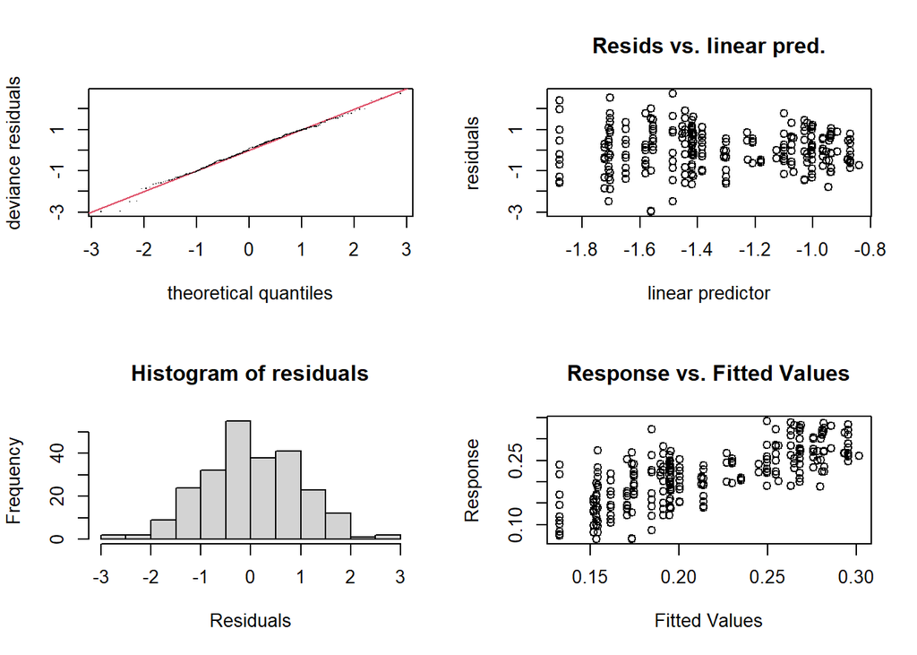

```
##
## Method: REML   Optimizer: outer newton
## full convergence after 6 iterations.
## Gradient range [-1.052572e-06,6.105759e-07]
## (score -388.7387 & scale 1).
## Hessian positive definite, eigenvalue range [0.09333612,116.0698].
## Model rank =  30 / 30
##
## Basis dimension (k) checking results. Low p-value (k-index<1) may
## indicate that k is too low, especially if edf is close to k'.
##
##                k'   edf k-index p-value
## te(LON,LAT) 24.00  4.94    1.01    0.49
## s(MLD)       4.00  2.48    0.93    0.12
```

```r
gam.check(fish)
```

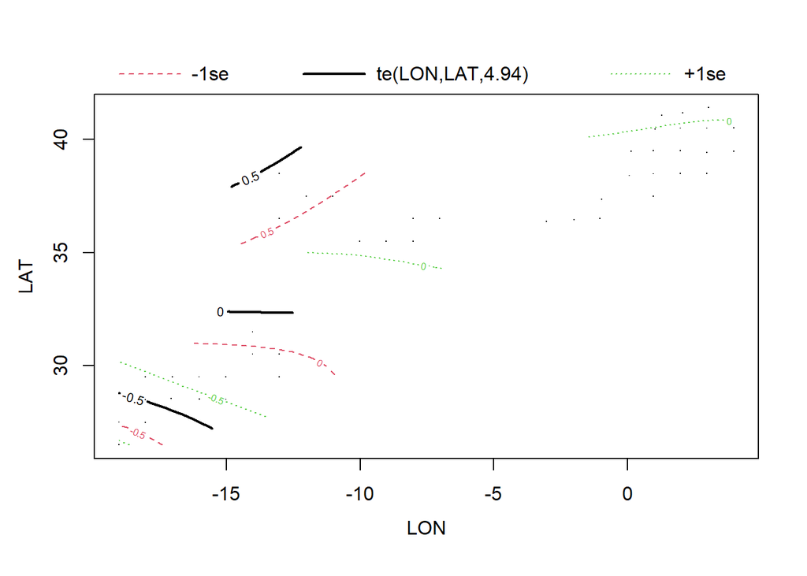

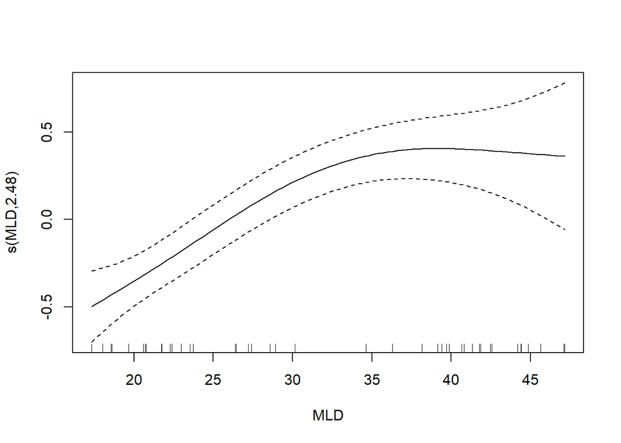

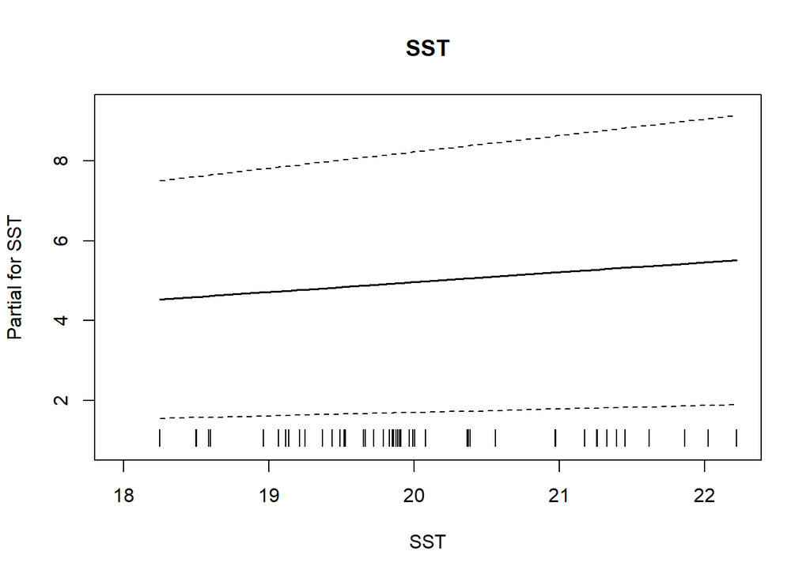

```r
plot(fish, all = T)
```

```r
AIC(fish)
```

```
## [1] -781.7923
```

```r
ceph = gam(ceph ~ te(LON, LAT) + s(LJFL, k = 5) + s(fishing_effort, k = 5) + SST, data=prey_grouped, family = betar(link = "logit"))
summary(ceph)
```

```
##
## Family: Beta regression(24.741)
## Link function: logit
##
## Formula:
## ceph ~ te(LON, LAT) + s(LJFL, k = 5) + s(fishing_effort, k = 5) +
##     SST
##
## Parametric coefficients:
##             Estimate Std. Error z value Pr(>|z|)
## (Intercept)   8.3765     4.2652   1.964   0.0495 *
## SST          -0.3906     0.2137  -1.828   0.0676 .
## ---
## Signif. codes:  0 '***' 0.001 '**' 0.01 '*' 0.05 '.' 0.1 ' ' 1
##
## Approximate significance of smooth terms:
##                      edf Ref.df Chi.sq  p-value
## te(LON,LAT)       10.899 12.491 195.36  < 2e-16 ***
## s(LJFL)            3.495  3.862  20.80 0.000744 ***
## s(fishing_effort)  3.522  3.819  13.29 0.006284 **
## ---
## Signif. codes:  0 '***' 0.001 '**' 0.01 '*' 0.05 '.' 0.1 ' ' 1
##
## R-sq.(adj) =  0.694   Deviance explained = 71.7%
## -REML = -213.81  Scale est. = 1         n = 241
```

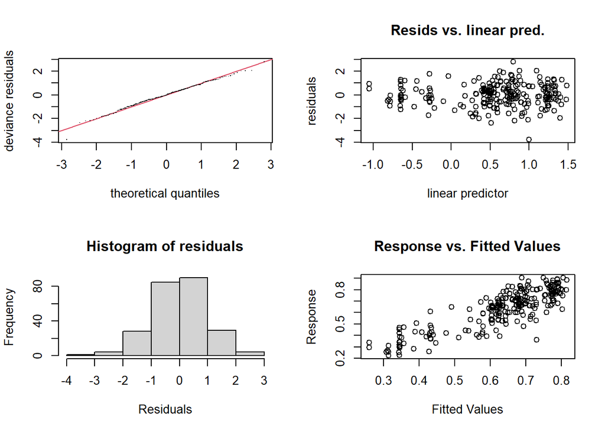

```
##
## Method: REML   Optimizer: outer newton
## full convergence after 7 iterations.
## Gradient range [-3.366558e-08,7.966439e-08]
## (score -213.8143 & scale 1).
## Hessian positive definite, eigenvalue range [0.5448125,112.9915].
## Model rank =  34 / 34
##
## Basis dimension (k) checking results. Low p-value (k-index<1) may
## indicate that k is too low, especially if edf is close to k'.
##
##                      k'   edf k-index p-value
## te(LON,LAT)       24.00 10.90    1.06    0.84
## s(LJFL)            4.00  3.49    1.08    0.92
## s(fishing_effort)  4.00  3.52    1.05    0.78
```

```r
gam.check(ceph)
```

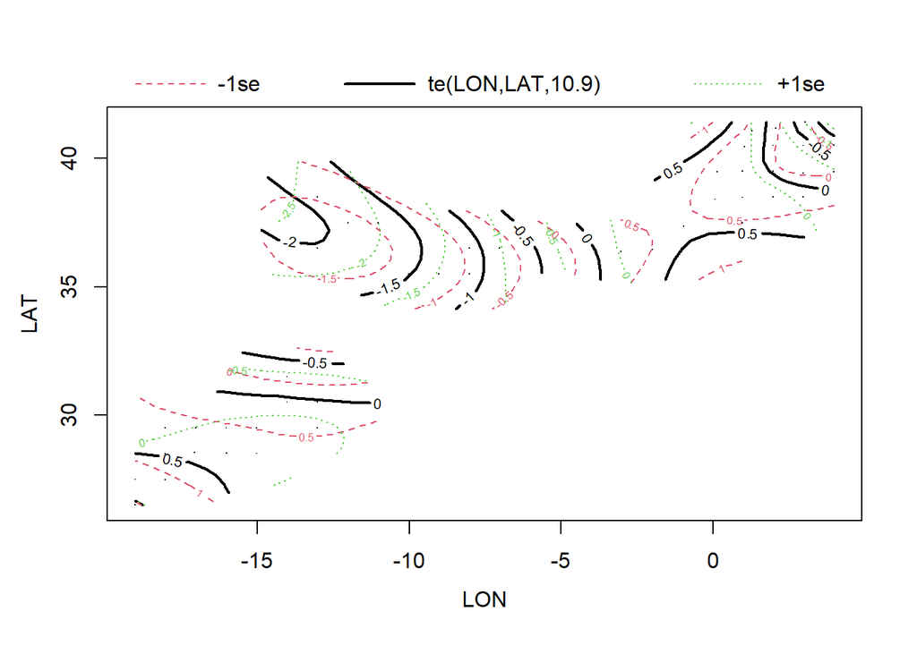

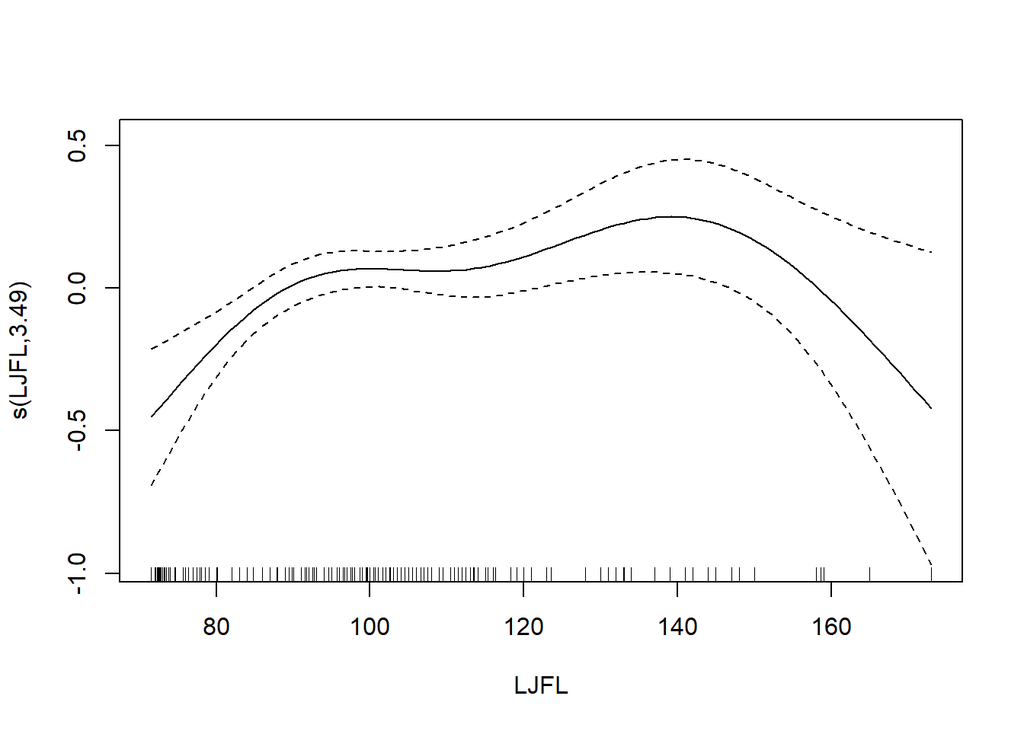

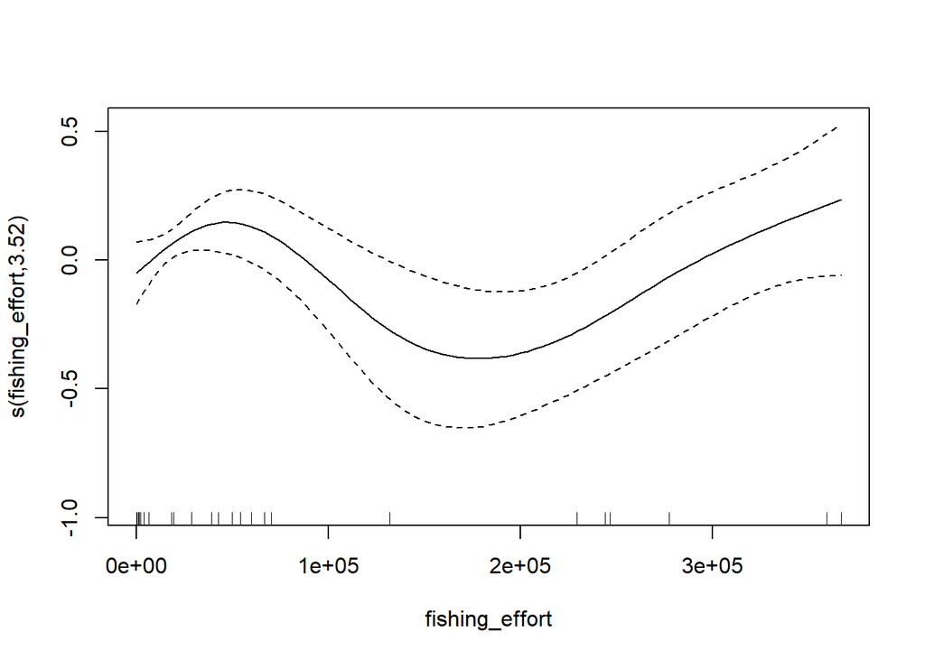

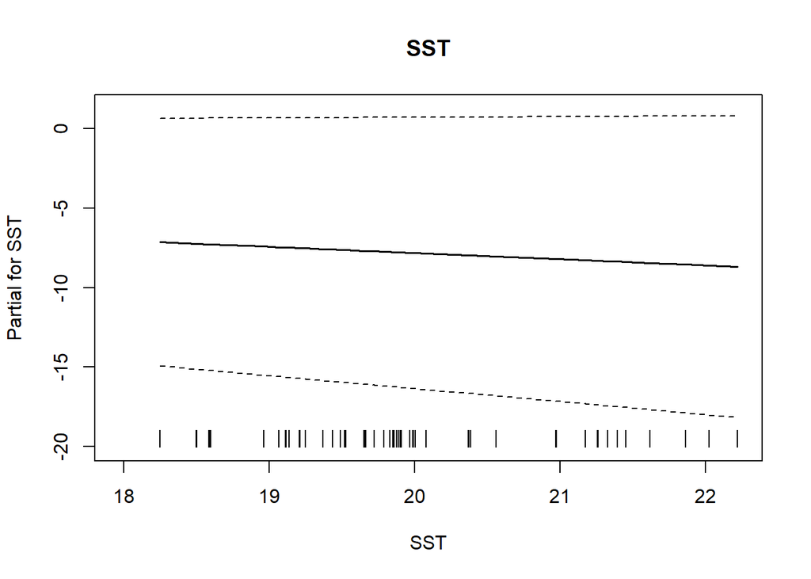

```r
plot(ceph, all =T)
```

```r
AIC(ceph)
```

```
## [1] -452.0674
```

```r
gela1 = gam(gela ~ te(LON,LAT) + s(LJFL, k=5) + Chlmean + s(fishing_effort, k = 5), data=prey_grouped, family = betar(link = "logit"))
summary(gela1)
```

```
##
## Family: Beta regression(30.429)
## Link function: logit
##
## Formula:
## gela ~ te(LON, LAT) + s(LJFL, k = 5) + Chlmean + s(fishing_effort,
##     k = 5)
##
## Parametric coefficients:
##             Estimate Std. Error z value Pr(>|z|)
## (Intercept)  -1.4848     0.1822  -8.148 3.71e-16 ***
## Chlmean      -1.9075     0.9523  -2.003   0.0452 *
## ---
## Signif. codes:  0 '***' 0.001 '**' 0.01 '*' 0.05 '.' 0.1 ' ' 1
##
## Approximate significance of smooth terms:
##                     edf Ref.df Chi.sq  p-value
## te(LON,LAT)       9.933 11.533 303.42  < 2e-16 ***
## s(LJFL)           3.462  3.842  26.94 1.79e-05 ***
## s(fishing_effort) 3.427  3.765  11.11   0.0226 *
## ---
## Signif. codes:  0 '***' 0.001 '**' 0.01 '*' 0.05 '.' 0.1 ' ' 1
##
## R-sq.(adj) =  0.696   Deviance explained = 71.6%
## -REML = -335.64  Scale est. = 1         n = 241
```

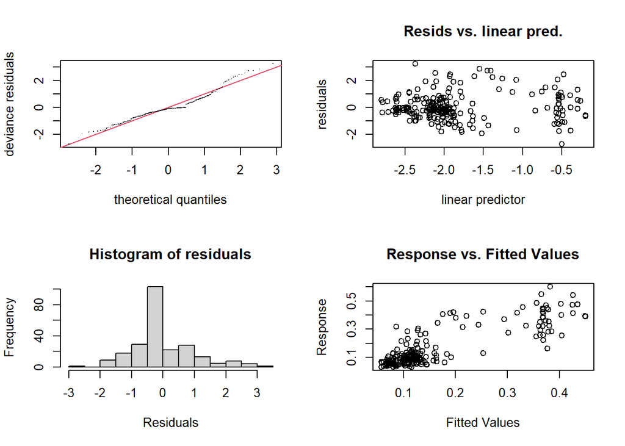

```
##
## Method: REML   Optimizer: outer newton
## full convergence after 7 iterations.
## Gradient range [-9.852899e-05,0.0001715129]
## (score -335.643 & scale 1).
## Hessian positive definite, eigenvalue range [0.4595888,109.7536].
## Model rank =  34 / 34
##
## Basis dimension (k) checking results. Low p-value (k-index<1) may
## indicate that k is too low, especially if edf is close to k'.
##
##                      k'   edf k-index p-value
## te(LON,LAT)       24.00  9.93    1.06    0.81
## s(LJFL)            4.00  3.46    1.14    0.99
## s(fishing_effort)  4.00  3.43    1.07    0.79
```

```r
gam.check(gela1)
```

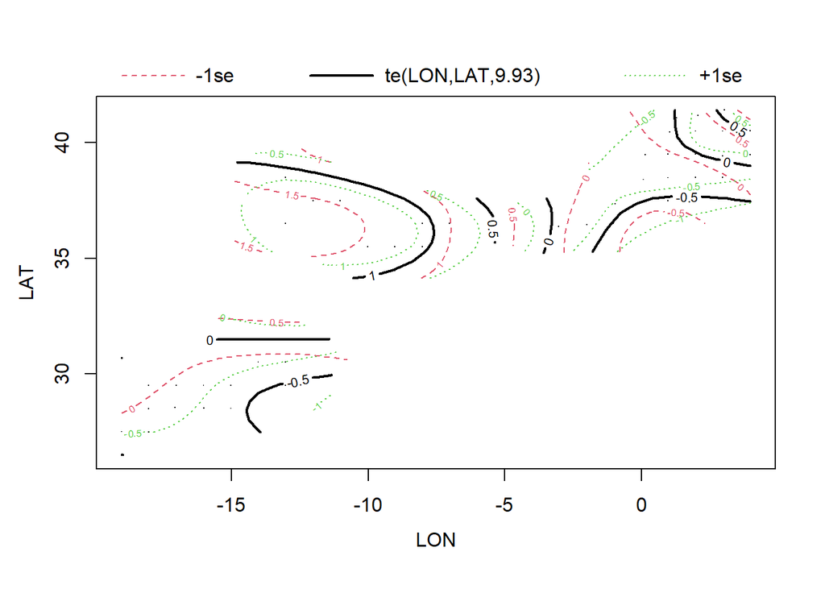

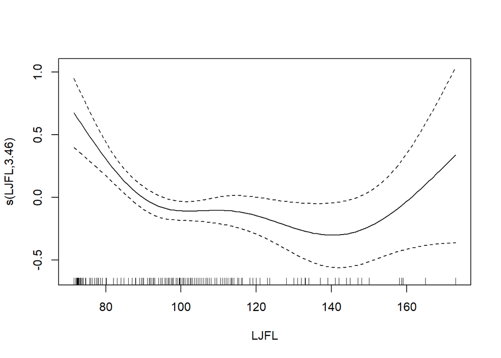

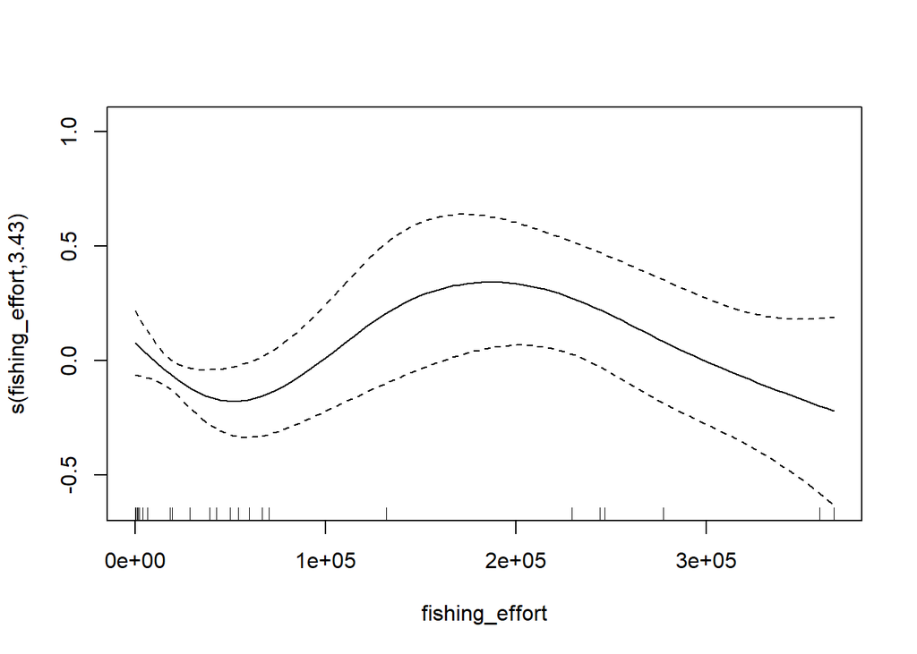

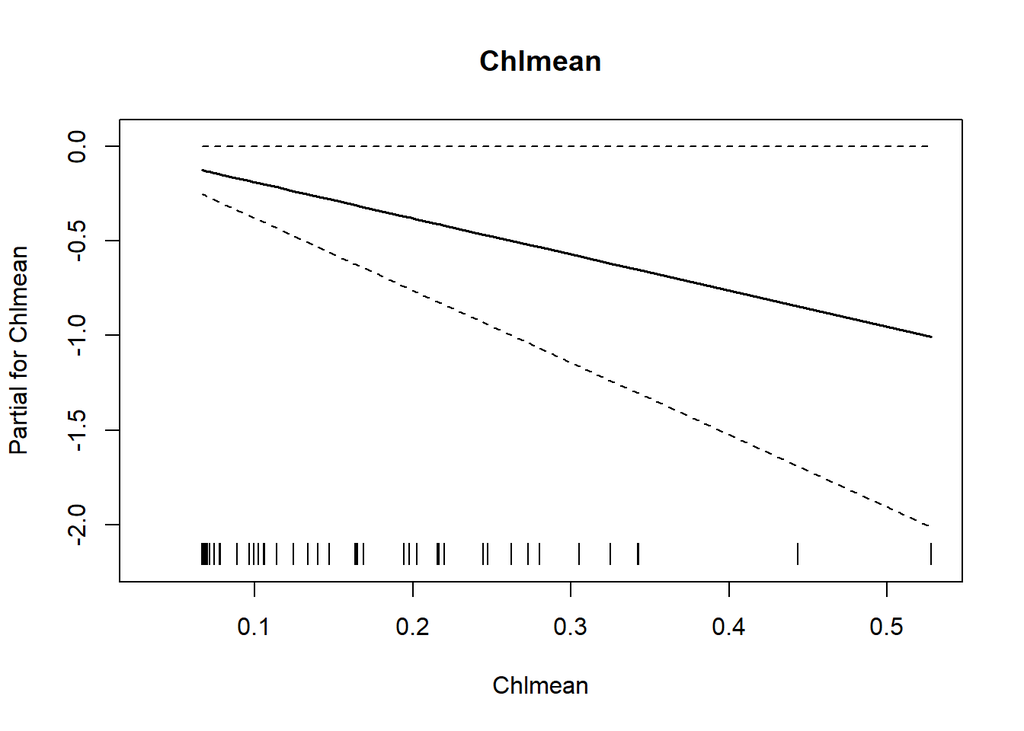

```r
plot(gela1, all = T)
```

```r
AIC(gela1)
```

```
## [1] -685.3925
```

# 3 Spatial autocorrelation

A common problem in the model that not takes into account the spatial component is the spatial autocorrelation. Let’s verify if our model and predictions have this problem.

The Moran’s I is a measure of spatial autocorrelation–how related the values of a variable are based on the locations where they were measured. The null hypothesis of this test is that there is no spatial autocorrelation. To calculate Moran’s I, we will need to generate a matrix of distance weights. Using the latitude and longitude values:

```r
library(sp)#For Moran test
library(spdep)#For Moran test
# Convert to spatial points
species_data3=prey_grouped
coordinates(species_data3) <- ~ LON + LAT

# Create k-nearest neighbors
knn_neighbors <- knn2nb(knearneigh(coordinates(species_data3), k=4))
listw <- nb2listw(knn_neighbors, style = "W")#Here the style  W = row standardized (rows sum to 1)

# Run Moran's I test
#we now test the moran test on residuals of the model
moran.test(residuals(fish), listw=listw)
```

```
##
##  Moran I test under randomisation
##
## data:  residuals(fish)
## weights: listw
##
## Moran I statistic standard deviate = -1.1361, p-value = 0.8721
## alternative hypothesis: greater
## sample estimates:
## Moran I statistic       Expectation          Variance
##      -0.049484978      -0.004166667       0.001591035
```

```r
moran.test(residuals(ceph), listw=listw)
```

```
##
##  Moran I test under randomisation
##
## data:  residuals(ceph)
## weights: listw
##
## Moran I statistic standard deviate = -2.677, p-value = 0.9963
## alternative hypothesis: greater
## sample estimates:
## Moran I statistic       Expectation          Variance
##      -0.110849540      -0.004166667       0.001588140
```

```r
moran.test(residuals(gela1), listw=listw)
```

```
##
##  Moran I test under randomisation
##
## data:  residuals(gela1)
## weights: listw
##
## Moran I statistic standard deviate = -2.1238, p-value = 0.9832
## alternative hypothesis: greater
## sample estimates:
## Moran I statistic       Expectation          Variance
##      -0.088692350      -0.004166667       0.001583987
```

Moran’s I Test Results Breakdown

Moran I Statistic: - positive values suggests that similar values (presence) tend to cluster together in space. In other words, areas with high values of presence are more likely to be surrounded by other areas with high presence.

Expectation: - Under the null hypothesis of no spatial autocorrelation, the expected value of Moran’s I is close to zero. A value near zero indicates that, on average, there is no spatial autocorrelation when considering random arrangements of points.

Variance: - This represents the variability of the Moran’s I statistic under the null hypothesis. It is used to assess the significance of the observed statistic.

Standard Deviations: - This value indicates how many standard deviations the observed Moran’s I is away from the expected value. A large value suggests a significant departure from randomness.

P-value: - Low p-value indicate that the result is highly significant. It means that there is strong evidence against the null hypothesis of no spatial autocorrelation. You can confidently conclude that there is a significant positive spatial correlation in your data.

Summary: Overall, these results suggest to accept the null hypothesis of no spatial autocorrelation